# 9.5_Reinforcement_part_1_PRESENTATION slides

Reinforcement Learning Series

Chi-Town Machine Learning Meetup

[figure not shown]

This presentation is supplementary material for the textbook Machine Learning Refined (Cambridge University Press, 2016). Visit [our book website](http://www.mlrefined.com) for free chapter downloads and tutorials, [our github page](https://github.com/jermwatt/mlrefined) for tons of code demos and notebooks, and [our Amazon site here](https://www.amazon.com/Machine-Learning-Refined-Foundations-Applications/dp/1107123526/ref=sr_1_1?ie=UTF8&qid=1474491657&sr=8-1&keywords=machine+learning+refined) for details regarding a hard copy of the text.

Reinforcement Learning Series

Chi-Town Machine Learning Meetup

Reinforcement Learning Series

Part 1: Fundamentals

[figure not shown]

# What this Series is all about

## What this Series is all about

- Learning RL is tough!
- Requires use of advanced ideas from machine learning
  - e.g., mathematical optimization, deep networks
- Series of talks introduces RL by pulling apart entire process
- We will develop important intuition about the strengths and limitations of Reinforcement paradigm.

# What this presentation is all about

## What this presentation is all about

- Here we introduce the fundamentals
- In particular: the Q-Learning algorithm
- Future talks cover more advanced concepts

  e.g., how to integrate in deep networks

# What is Reinforcement Learning (RL)?

- A general framework for building computational agents which can, if trained properly, act intelligently in a well-defined but dynamic environment.
- Three main application areas in which RL is commonly used: robotics, automatic control, and game AI.

# Common applications of Reinforcement?

## Example: Robotics (e.g., shortest path) - Gridworld

[figure not shown]

## Example: Robotics (e.g., shortest path) - Gridworld

[figure not shown]

## Example: Robotics (e.g., shortest path - Gridworld

[figure not shown]

## Example: Game playing agents

[figure not shown]

## Example: Game playing agents

[figure not shown]

### Example: Control problems (e.g., inverted pendulum)

[figure not shown]

### Example: Control problems (e.g., lunar lander)

[figure not shown]

# Principles of Reinforcement

# Principles of Reinforcement

- **Principle 1:** Reinforcement Learning automates narrowly focused goal-driven tasks. Narrowly focused $\neq$ simple.

[figure not shown]

- **Principle 2:** Experimentation in the space of a problem - commonly a realistic simulation of a problem's environment - is crucial to training a Reinforcement Learning agent.
- **Principle 3:** A Reinforcement Learning agent learns by repeated trial-and-error interactions with a problem environment or simulator.

[figure not shown]

- **Principle 4:** Numerical rewards are used to communicate the desired goal to the Reinforcement Learning agent.

# The fundamental components of an RL problem

# The fundamental components of an RL problem

1. A **state** is a specific configuration of all objects in a problem's environment

```
- Defined by environment
```

2. The agent can then take an **action**

```
- Defined by environment
```

3. A **reward** is a numerical signal communicating our desired goal to the agent

```
- Defined by we humans
```

## Example: Gridworld

- A **state** current location of the player (the blue square).
- **Actions** the agent can one square adjacently up, down, left or right.
- **Rewards**
  - -1 to all actions leading to non-goal/non-hazard
  - -100 for those leading to hazard
  - 0 for actions leading to goal

## Example: Chess

- A **state** is any (legal) configuration of the white and black pieces.
- An **action** is any legal move of current piece on the board.
- **Rewards**
  - action leading to checkmate gives 10000
  - every other action gives -1

## Example: Inverted pendulum

- a **state** is a complete set of information about the cart and pole's position
- An **action** is moving the cart left or right along the horizontal axis by one unit.
- **Rewards**
  - angle between the pole and the horizontal axis is above a certain threshold the reward 1
  - otherwise reward is 0

# Formalities and jargon of Reinforcement

# Modeling and jargon of Reinforcement

- **Principle 3:** A Reinforcement Learning agent learns by repeated trial-and-error interactions with a problem environment or simulator.

[figure not shown]

1. Run through many **simulations**

2. Each simulation run is called an **episode**

3. Each movement is called a **step**

[figure not shown]

4. Each step consists of 4 events:

```
- begin at a state
- take an action
- move to a new state based on action taken
- receive reward based on action taken
```

# Formal modeling: an episode of steps

# Formal modeling: an episode of steps

**step 1:**

- start at an initial state (denoted by $s_0$)
- take an action (denoted by $a_1$)
- arrive at state (denoted by $s_1$), receive first reward $r_1$

**step 2:**

- start at state $s_1$
- take an action (denoted by $a_2$)
- arrive at new state (denoted by $s_2$) and receive second reward $r_2$

**step 3:**

- start at state $s_2$
- take an action (denoted by $a_3$)
- arrive at new state (denoted by $s_3$) and and receive third reward $r_3$

**step 4:**  
...

Written more compactly as:

($s_0$, $a_1$, $r_1$), ($s_1$, $a_2$, $r_2$), ($s_2$, $a_3$, $r_3$), ($s_3$,...

# Step back: what are we after again?

- simulations $\longrightarrow$ episodes $\longrightarrow$ steps

($s_0$, $a_1$, $r_1$), ($s_1$, $a_2$, $r_2$), ($s_2$, $a_3$, $r_3$), ($s_3$,...

- want: **optimal actions leading to greatest long-term reward**

# Reinforcement fundamentals: the Q cost function

# The Q cost function

- want: **optimal actions leading to greatest long-term reward**
- expressing this desire in math gives us so-called Q cost
- derivation uses common math trick
- assume what you want, use it to derive (**recursive equations**)

## The Q cost function: derivation

- take a sequence of steps:

($s_0$, $a_1$, $r_1$), ($s_1$, $a_2$, $r_2$), ($s_2$, $a_3$, $r_3$), ($s_3$,...

- start at $s_0$ $\longrightarrow$ take any first action $a_1$ $\longrightarrow$ recieve reward $r_1$
- **now assume every further action is optimal**
- denote the resulting maximal long-term reward: $Q(s_0,a_1)$

## The Q cost function: derivation

- denote the resulting maximal long-term reward by $Q(s_0,a_1)$
- only action **not** potentially optimal is first at $s_0$ i.e., $a_1$
- then maximum total reward from $s_0$ : $\underset{i}{\text{maximum}}\,\,Q\left(s_{0},\,\alpha_{i}\right)$

## The Q cost function: derivation

- then maximum total reward from $s_0$ is: $\underset{i}{\text{maximum}}\,\,Q\left(s_{0},\,\alpha_{i}\right)$
- with this $Q$ is defined *recursively* in terms of itself
- $Q(s_0,a_1)$ must be the sum of $r_1$ **and** the *maximum possible sum of rewards for all subsequent steps:* $\underset{i}{\text{maximum}}\,\,Q\left(s_{1},\,\alpha_{i}\right)$.
- Algebraically: $Q\left(s_{0},\,a_{1}\right)=r_{1}+\underset{i=1}{\text{maximum}}\,\,Q\left(s_{1},\,\alpha_{i}\right)$

## The Q cost function: derivation

So can approximate $Q$ by running through an episode of simulation

($s_0$, $a_1$, $r_1$), ($s_1$, $a_2$, $r_2$), ($s_2$, $a_3$, $r_3$), ($s_3$,...

and updating $Q$ recursively at each step:

$Q\left(s_{0},\,a_{1}\right)=r_{1}+\underset{i=1...M}{\text{maximum}}\,\,Q\left(s_{1},\,\alpha_{i}\right)$

$Q\left(s_{1},\,a_{2}\right)=r_{2}+\underset{i=1...M}{\text{maximum}}\,\,Q\left(s_{2},\,\alpha_{i}\right)$

$Q\left(s_{2},\,a_{3}\right)=r_{3}+\underset{i=1...M}{\text{maximum}}\,\,Q\left(s_{3},\,\alpha_{i}\right)$

$\vdots$

$Q\left(s_{k-1},\,a_{k}\right)=r_{k}+\underset{i=1...M}{\text{maximum}}\,\,Q\left(s_{k},\,\alpha_{i}\right)$

$\vdots$

## The Q cost function: derivation

- This is called **the Q-Learning Algorithm**
- works by approximating $Q$ iteratively
- updating $Q$ recursively at each step of each simulation
- exactly as shown here

[figure not shown]

### Q -learning pseudo-code

Initialize $Q$

**for** e = 1...E (the maximum number of episodes)

Select a random initial state $s_0$ and set $k=1$

**while** end state not reached AND maximum iteration count not met

select the action $a_k$ at random and record the resulting state $s_k$ and corresponding reward $r_k$

update $Q$ as

$Q\left(s_{k-1},\,a_{k}\right)=r_{k}+\underset{i=1...M}{\text{maximum}}\,\,Q\left(s_{k},\,\alpha_{i}\right)$

$k \longleftarrow k+1$

# Q-learning for the gridworld maze

```python
### start main Q-learning loop ###
for n in range(self.training_episodes):
    # pick this episode's starting position
    grid.agent = self.training_start_schedule[n]

    # update Q matrix while loc != goal
    episode_history = []      # container for storing this episode's journey
    total_episode_reward = 0
    for step in range(self.max_steps):
        # update episode history container
        episode_history.append(grid.agent)

        ### if you reach the goal end current episode immediately
        if grid.agent == grid.goal:
            break

        # translate current agent location tuple into index
        s_k_1 = grid.state_tuple_to_index(grid.agent)

        # get action
        a_k = grid.get_action(method = self.action_method,Q = Q,exploit_param = self.exploit_param)

        # move based on this action
        s_k = grid.get_movin(action = a_k)

        # get reward
        r_k = grid.get_reward(state_index = s_k)

        # update Q
        Q[s_k_1,a_k] = r_k + max(Q[s_k,:])

        # update current location of agent
        grid.agent = grid.state_index_to_tuple(state_index = s_k)
```

## Applying Q-learning to the gridworld maze

```python
# import gridworld library - make sure this is executed prior to running any gridworld cell
import sys
sys.path.append('demo_python_backend_files')
%matplotlib inline
```

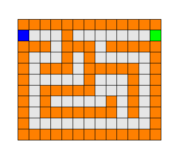

```python
# import custom gridworld simulator
from gridworld_lib import gridworld_enviro

# generate instance of gridworld
small_maze = gridworld_enviro.environment(world_size = 'small', world_type = 'maze')

# show the grid
small_maze.color_gridworld()
```

## Applying Q-learning to the gridworld maze

```python
# import q-learning module
from gridworld_lib import gridworld_qlearn

# create an instance of the q-learner
qlearner = gridworld_qlearn.learner(gridworld = small_maze,action_method = 'random')

# run q-learning
qlearner.train(verbose = True)
```

```
training episode 50 of 500 complete
training episode 100 of 500 complete
training episode 150 of 500 complete
training episode 200 of 500 complete
training episode 250 of 500 complete
training episode 300 of 500 complete
training episode 350 of 500 complete
training episode 400 of 500 complete
training episode 450 of 500 complete
training episode 500 of 500 complete
q-learning algorithm complete
```

```python
# load in gridworld animation module
from gridworld_lib import gridworld_animators

# create instance of animator
animator = gridworld_animators.animator()

### animate training runs of one algorithm ###
animator.animate_training_runs(gridworld = small_maze, learner = qlearner,episodes = [1,25,30,100])
```

[figure not shown]

## Does Q-Learning work?

## Does Q-Learning work?

```python
# load in gridworld animation module
from gridworld_lib import gridworld_animators

# create instance of animator
animator = gridworld_animators.animator()

# animate a fully trained agent
locs = [[9,0],[0,0],[5,5]]
animator.animate_validation_runs(gridworld = small_maze,learner = qlearner,starting_locations = locs)
```

[figure not shown]

# How about on other gridworlds?

# how about a random world?

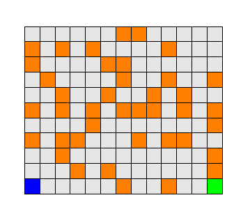

```python
# import custom gridworld simulator
from gridworld_lib import gridworld_enviro

# generate instance of gridworld
small_maze = gridworld_enviro.environment(world_size = 'small', world_type = 'random')

# show the grid
small_maze.color_gridworld()
```

```python
# import q-learning module
from gridworld_lib import gridworld_qlearn

# create an instance of the q-learner
qlearner = gridworld_qlearn.learner(gridworld = small_maze,action_method = 'random')

# run q-learning
qlearner.train(verbose = True)
```

```
training episode 50 of 500 complete
training episode 100 of 500 complete
training episode 150 of 500 complete
training episode 200 of 500 complete
training episode 250 of 500 complete
training episode 300 of 500 complete
training episode 350 of 500 complete
training episode 400 of 500 complete
training episode 450 of 500 complete
training episode 500 of 500 complete
q-learning algorithm complete
```

```python
# load in gridworld animation module
from gridworld_lib import gridworld_animators

# create instance of animator
animator = gridworld_animators.animator()

# animate a fully trained agent
locs = [[9,0],[0,0],[5,5]]
animator.animate_validation_runs(gridworld = small_maze,learner = qlearner,starting_locations = locs)
```

[figure not shown]

# How about the moat (of doom?!!!)

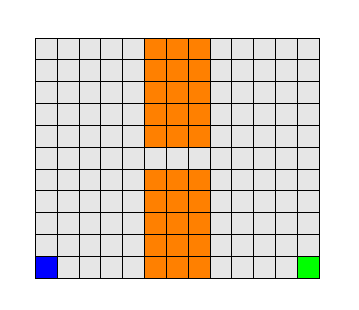

```python
# import custom gridworld simulator
from gridworld_lib import gridworld_enviro

# generate instance of gridworld
small_maze = gridworld_enviro.environment(world_size = 'small', world_type = 'moat')

# show the grid
small_maze.color_gridworld()
```

```python
# import q-learning module
from gridworld_lib import gridworld_qlearn

# create an instance of the q-learner
qlearner = gridworld_qlearn.learner(gridworld = small_maze,action_method = 'random')

# run q-learning
qlearner.train(verbose = True)
```

```
training episode 50 of 500 complete
training episode 100 of 500 complete
training episode 150 of 500 complete
training episode 200 of 500 complete
training episode 250 of 500 complete
training episode 300 of 500 complete
training episode 350 of 500 complete
training episode 400 of 500 complete
training episode 450 of 500 complete
training episode 500 of 500 complete
q-learning algorithm complete
```

```python
# load in gridworld animation module
from gridworld_lib import gridworld_animators

# create instance of animator
animator = gridworld_animators.animator()

# animate a fully trained agent
locs = [[9,0],[0,0],[5,5]]
animator.animate_validation_runs(gridworld = small_maze,learner = qlearner,starting_locations = locs)
```

[figure not shown]

# Summary

- discussed basic principles involved in Reinforcement Learning
- the components (state, action, rewards)
- common notation and jargon
- derivation of fundamental $Q$ function Q-Learning algorithm

## Coming up next in the Reinforcement Learning Series...

- common enhancements for the basic Q-Learning scheme discussed here
- features, mathematical optimization + RL
- why and how common function approximators such as deep neural etworks are integrated into the Reinforcement framework
- many more implementations of RL applied to control and game AI problems

## Notes and bibliography

[0] Harmon, Mance E., and Stephanie S. Harmon. Reinforcement Learning: A Tutorial. No. WL-TR-97-1028. WRIGHT LAB WRIGHT-PATTERSON AFB OH, 1997

[1] There are many algorithms specifically designed to solve just this task - the most popular being [Dijkstra’s and A* algorithms](http://www.redblobgames.com/pathfinding/a-star/introduction.html). However the more flexible RL framework too provides great results.

[2] Lai, Matthew. "Giraffe: Using deep reinforcement learning to play chess." arXiv preprint arXiv:1509.01549 (2015). APA

[3] Mnih, Volodymyr, et al. "Playing atari with deep reinforcement learning." arXiv preprint arXiv:1312.5602 (2013).

[4] Image taken from http://ai.berkeley.edu/project_overview.html

[5] Watkins, Christopher JCH, and Peter Dayan. "Q-learning." Machine learning 8.3-4 (1992): 279-292.

[6] Image taken from https://gym.openai.com/